# Chap2.4-2.5

Mijeong Kim

## 2.4 계절성 그래프 (Seasonal plots)

계절성 그래프는 시간 그래프(time plot)와 유사하지만, 데이터가 관측된 개별 “계절(season)”에 대해 플로팅된다는 점이 다르다.

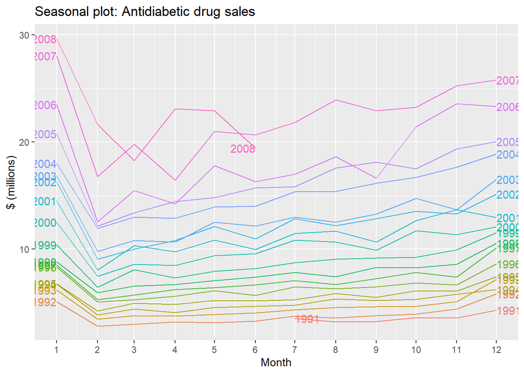

```r
a10 <- PBS %>%
  filter(ATC2 == "A10") %>%
  select(Month, Concession, Type, Cost) %>%
  summarise(TotalC = sum(Cost)) %>%
  mutate(Cost = TotalC / 1e6)


a10 |>
  gg_season(Cost, labels = "both") +
  labs(y = "$ (millions)",
       title = "Seasonal plot: Antidiabetic drug sales")
```

이 그래프는 앞서 보여준 것과 동일한 데이터를 사용하지만, 각 연도의 데이터가 겹쳐서 표시된다. 계절성 그래프는 기본적인 계절 패턴을 더 명확하게 볼 수 있도록 해주며, 특정 연도에서 패턴이 변화하는지를 식별하는 데 유용하다.

각 연도의 1월에 판매량이 급증하는 것을 확인할 수 있다. 이는 아마도 고객들이 연말(12월)에 미리 약을 대량 구매하여 재고를 확보하기 때문일 가능성이 크다. 하지만 실제 판매 데이터는 정부에 1~2주 후에 등록되므로 1월에 반영된 것이다. 또한 2008년 3월의 판매량이 다른 연도에 비해 유난히 낮다는 점도 눈에 띈다(대부분의 연도에서는 2월에서 3월로 가면서 증가하는 패턴을 보임). 2008년 6월의 판매량이 낮은 이유는 데이터 수집 당시 판매량 집계가 완료되지 않았기 때문일 가능성이 높다.

### 복수의 계절성 주기 (Multiple seasonal periods)

하나의 데이터에 둘 이상의 계절성 패턴이 존재할 경우, period 인수를 사용하여 원하는 계절성 패턴을 선택할 수 있다. 예를 들어, vic_elec 데이터에는 호주 빅토리아주의 30분 단위 전력 수요 데이터가 포함되어 있다. 이를 이용해 일별, 주별, 연간 패턴을 각각 나타낼 수 있으며, 아래 코드와 같이 period 옵션을 지정하면 된다.

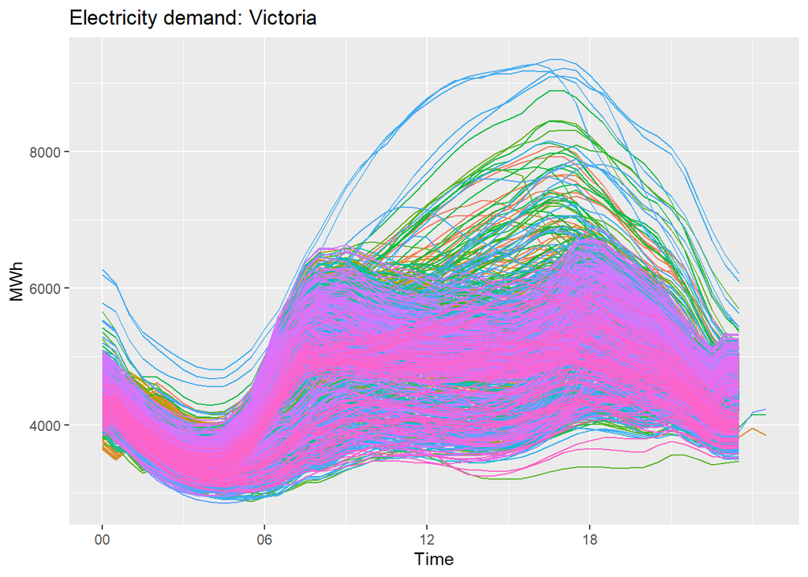

```r
# 일별 계절성 패턴
vic_elec |> gg_season(Demand, period = "day") +
  theme(legend.position = "none") +
  labs(y="MWh", title="Electricity demand: Victoria")
```

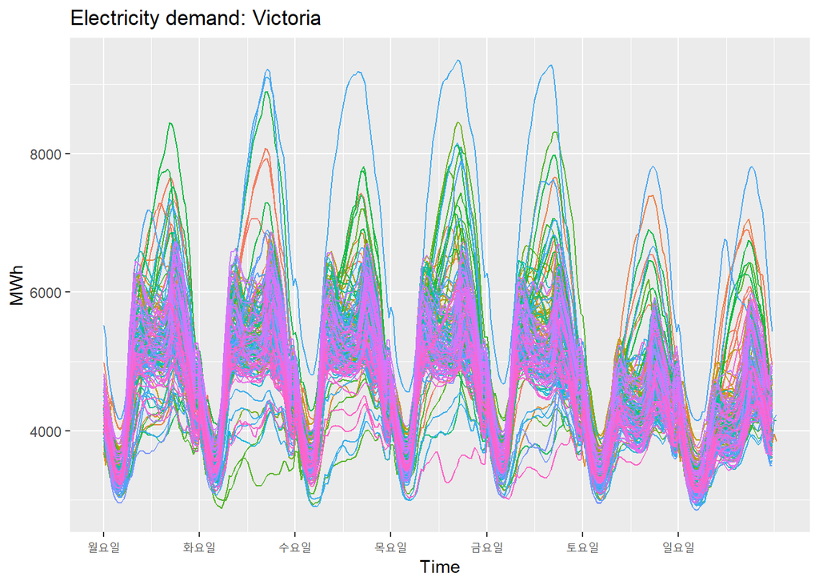

```r
# 주별 계절성 패턴
vic_elec |> gg_season(Demand, period = "week") +
  theme(legend.position = "none") +
  labs(y="MWh", title="Electricity demand: Victoria")
```

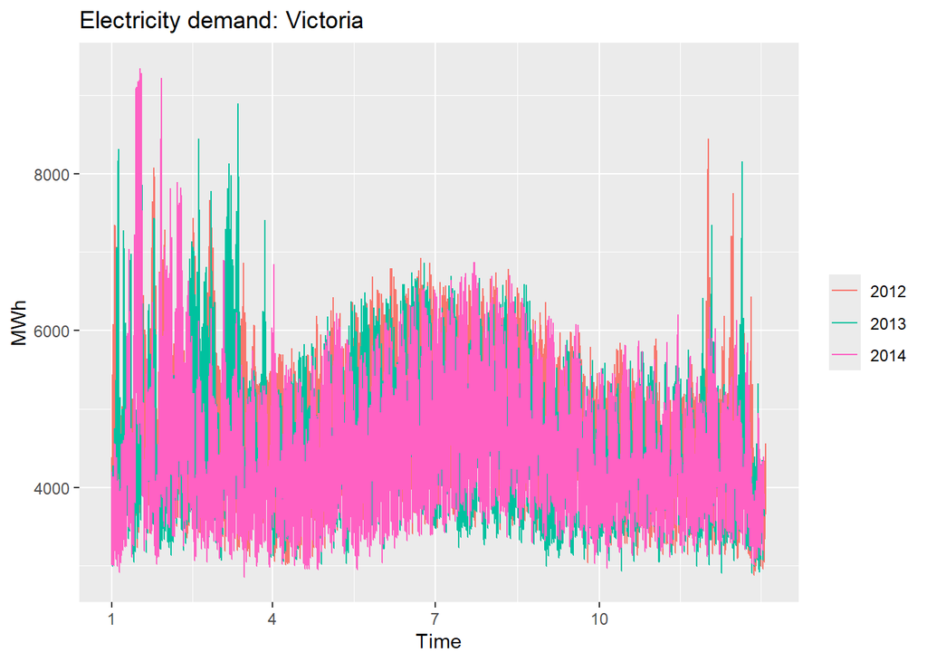

```r
# 연간 계절성 패턴
vic_elec |> gg_season(Demand, period = "year") +
  labs(y="MWh", title="Electricity demand: Victoria")
```

그림 2.5: 빅토리아 전력 수요의 일별 계절성 패턴 그림 2.6: 빅토리아 전력 수요의 주별 계절성 패턴 그림 2.7: 빅토리아 전력 수요의 연간 계절성 패턴

위 그래프 중 첫 번째(일별 패턴)에서, 하루가 25시간인 경우가 세 번 나타나는데, 이는 일광 절약 시간제(daylight saving)가 종료된 날들이기 때문이다. 이러한 날들은 한 시간이 추가되므로 하루 25시간이 된다. 반면, 일광 절약 시간제가 시작될 때는 하루 23시간이 되지만, 그래프에서 다른 데이터와 겹쳐 보이지 않을 수도 있다.

## 2.5 계절성 부분 그래프 (Seasonal Subseries Plots)

### 항당뇨제 판매 데이터 계절성 부분 분석

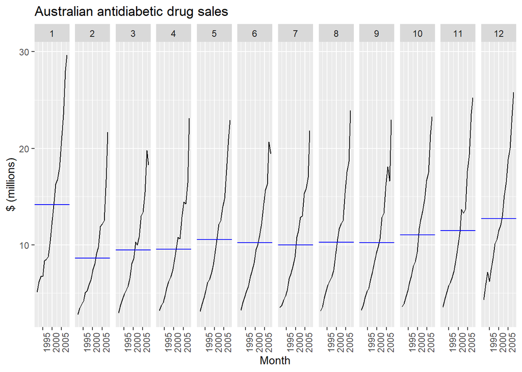

```r
library(ggplot2)
library(fpp3)  # Forecasting 패키지

a10 |>
  gg_subseries(Cost) +
  labs(y = "$ (millions)",
       title = "Australian antidiabetic drug sales")
```

> 위 그래프는 각 월별 평균값을 파란색 선으로 표시하여 계절성을 강조했다.  
> 시간에 따른 계절 패턴의 변화를 확인하는 데 유용하다.

### 호주의 휴가 관광 데이터 분석

#### (1) 데이터 추출 및 시간 그래프

```r
holidays <- tourism |>
  filter(Purpose == "Holiday") |>
  group_by(State) |>
  summarise(Trips = sum(Trips))

holidays
```

```
## # A tsibble: 640 x 3 [1Q]
## # Key:       State [8]
##    State Quarter Trips
##    <chr>   <qtr> <dbl>
##  1 ACT   1998 Q1  196.
##  2 ACT   1998 Q2  127.
##  3 ACT   1998 Q3  111.
##  4 ACT   1998 Q4  170.
##  5 ACT   1999 Q1  108.
##  6 ACT   1999 Q2  125.
##  7 ACT   1999 Q3  178.
##  8 ACT   1999 Q4  218.
##  9 ACT   2000 Q1  158.
## 10 ACT   2000 Q2  155.
## # ℹ 630 more rows
```

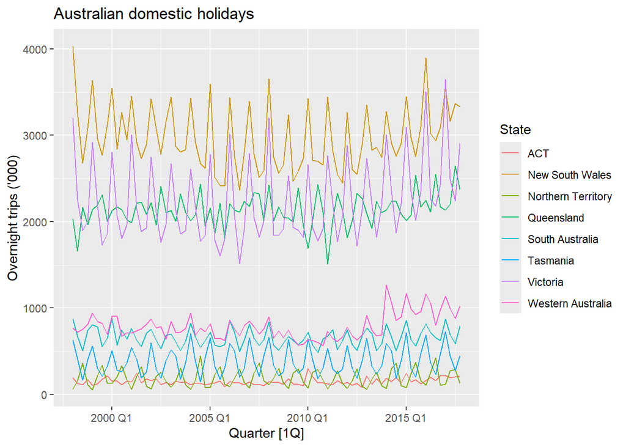

```r
autoplot(holidays, Trips) +
  labs(y = "Overnight trips ('000)",
       title = "Australian domestic holidays")
```

> 대부분의 주에서 강한 계절성이 보이지만, 관광 성수기가 일치하지 않는다.

#### (2) 계절성 그래프

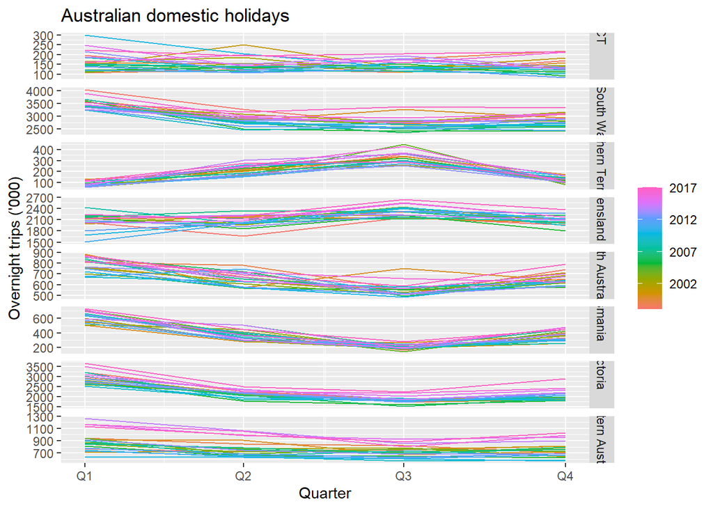

```r
gg_season(holidays, Trips) +
  labs(y = "Overnight trips ('000)",
       title = "Australian domestic holidays")
```

> 남부 지역(태즈메이니아, 빅토리아, 남호주)은 1분기에,  
> 북부 지역(퀸즐랜드, 노던 테리토리)은 3분기에 관광이 가장 활발하다.

#### (3) 계절성 부분 그래프

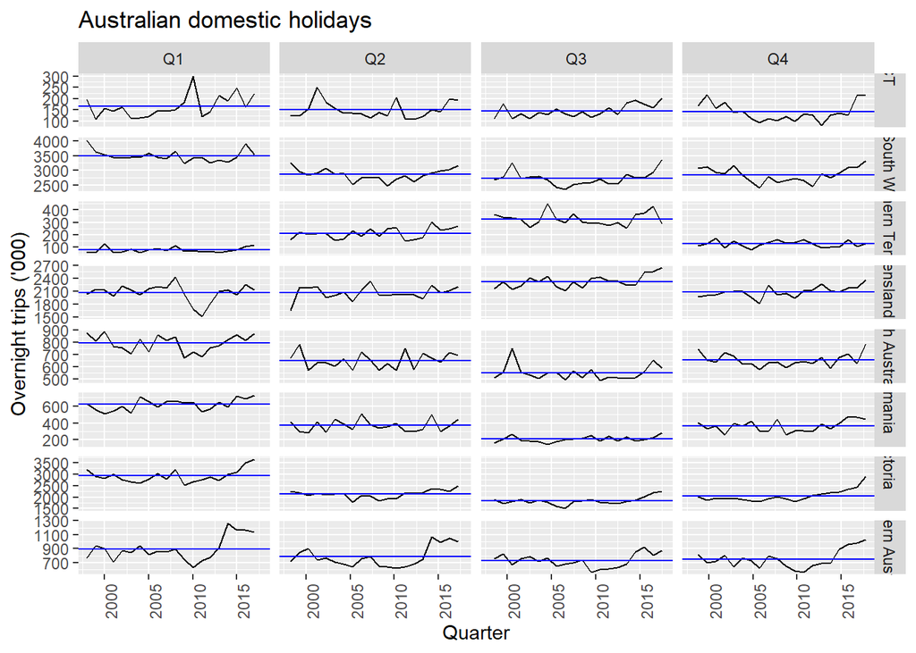

```r
holidays |> gg_subseries(Trips) +
  labs(y = "Overnight trips ('000)",
       title = "Australian domestic holidays")
```

> 서호주의 관광이 최근 몇 년간 급증했으며,  
> 빅토리아의 관광은 1분기와 4분기에 증가했으나 중간 분기에는 변화가 없음을 확인할 수 있다.